# Visualization and summary

Kauê de Sousa

2021

# Set up

For this lecture we need to packages PlackettLuce, ggplot2, gosset and igraph. We load the packages with `library()`. We also load some extra functions from the workflow employed in the ClimMob platform.

```r
library("PlackettLuce")
library("ggplot2")
library("gosset")
library("igraph")
source("https://raw.githubusercontent.com/AgrDataSci/ClimMob-analysis/master/R/functions.R")
```

# Example 1: Beans data

Load the data of beans tricot trials from the package PlackettLuce

```r
data("beans", package = "PlackettLuce")
str(beans)
```

```
## 'data.frame':    842 obs. of  14 variables:
##  $ variety_a    : chr  "BRT 103-182" "INTA Rojo" "INTA Ferroso" "INTA Centro Sur" ...
##  $ variety_b    : chr  "SJC 730-79" "INTA Centro Sur" "INTA Matagalpa" "INTA Rojo" ...
##  $ variety_c    : chr  "PM2 Don Rey" "INTA Sequia" "BRT 103-182" "ALS 0532-6" ...
##  $ best         : chr  "C" "B" "A" "B" ...
##  $ worst        : chr  "A" "A" "C" "C" ...
##  $ var_a        : chr  "Worse" "Worse" "Better" "Better" ...
##  $ var_b        : chr  "Worse" "Better" "Worse" "Better" ...
##  $ var_c        : chr  "Better" "Better" "Worse" "Better" ...
##  $ season       : Factor w/ 5 levels "Po - 15","Ap - 15",..: 2 2 2 2 2 2 2 2 2 2 ...
##  $ year         : num  2015 2015 2015 2015 2015 ...
##  $ maxTN        : num  19.4 18.9 18.4 18.9 18.9 ...
##  $ lon          : num  -85.7 -85.4 -85.4 -85.4 -85.4 ...
##  $ lat          : num  13.1 13.3 13.3 13.3 13.3 ...
##  $ planting_date: Date, format: "2015-12-18" "2015-12-18" ...
```

## Contingency table

The function `table()` builds a contingency table of the counts at each combination of characters or factor levels. Let’s see the number of points in the beans data per season.

```r
table(beans$season)
```

```
##
## Po - 15 Ap - 15 Pr - 16 Po - 16 Ap - 16
##     177     481      64      33      87
```

Now number of varieties that were tested in the project. For this we use the function `unlist()` to coerce the three columns with the variety names into a vector of length 2526 (nrow(beans) x 3)

```r
items <- unlist(beans[,c("variety_a", "variety_b", "variety_c")])

table(items)
```

```
## items
##      ALS 0532-6     BRT 103-182 INTA Centro Sur    INTA Ferroso  INTA Matagalpa
##             261             245             260             234             258
##     INTA Precoz       INTA Rojo     INTA Sequia     PM2 Don Rey      SJC 730-79
##             246             249             259             244             270
```

And now we see how these varieties were tested across each season. For this, we pass the vector items as first argument and repeat the vector beans$season three times to match the length of the items using the function `rep()`.

```r
table(items, rep(beans$season, 3))
```

```
##
## items             Po - 15 Ap - 15 Pr - 16 Po - 16 Ap - 16
##   ALS 0532-6           58     149      18      11      25
##   BRT 103-182          51     140      18       9      27
##   INTA Centro Sur      56     143      21      12      28
##   INTA Ferroso         47     135      20       9      23
##   INTA Matagalpa       53     152      19       9      25
##   INTA Precoz          56     134      19      10      27
##   INTA Rojo            45     144      19      11      30
##   INTA Sequia          52     152      19      10      26
##   PM2 Don Rey          54     139      16      10      25
##   SJC 730-79           59     155      23       8      25
```

## Plot methods

We can use the function `density()` to compute a kernel density estimate of the maximum night temperature registed in the locations where the on-farm trials were stablished. To visualize this density, we use the function `plot()`.

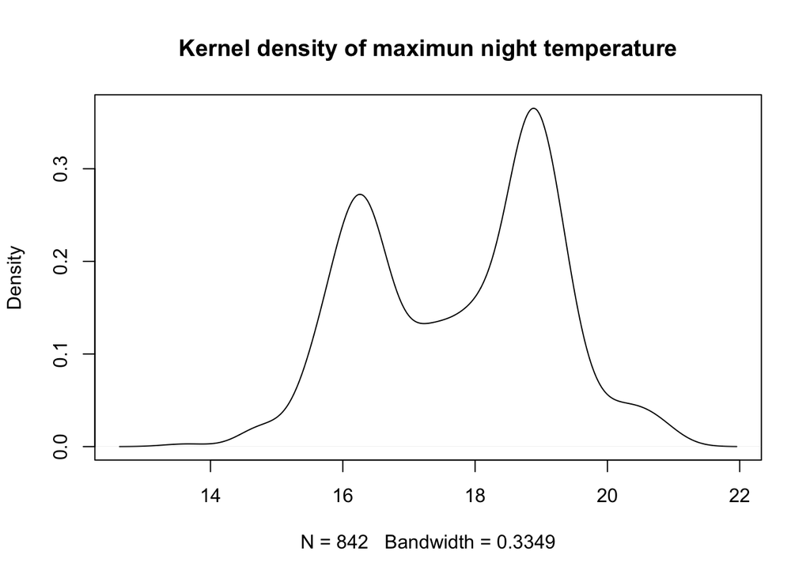

```r
plot(density(beans$maxTN),
     main = "Kernel density of maximun night temperature")
```

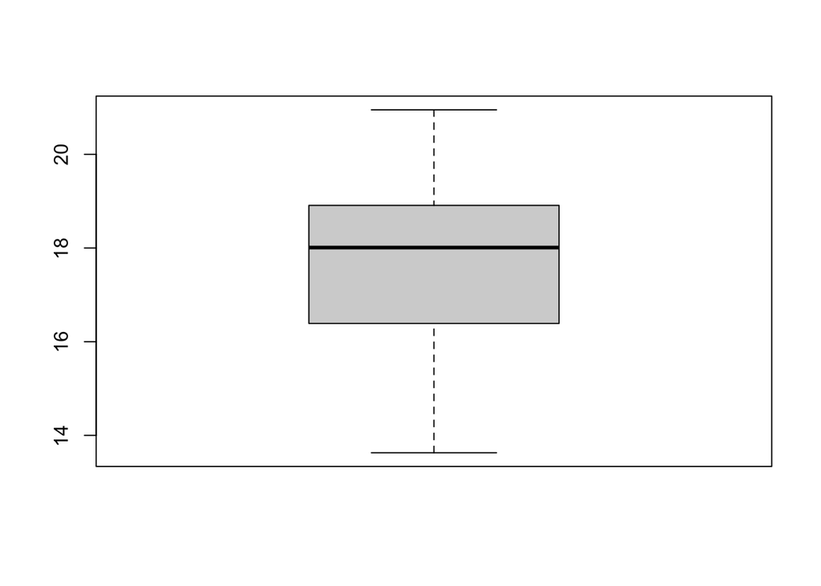

```r
boxplot(beans$maxTN)
```

With the function `plot()` we can also plot the coordinates of each on-farm trial registered in the bean trial.

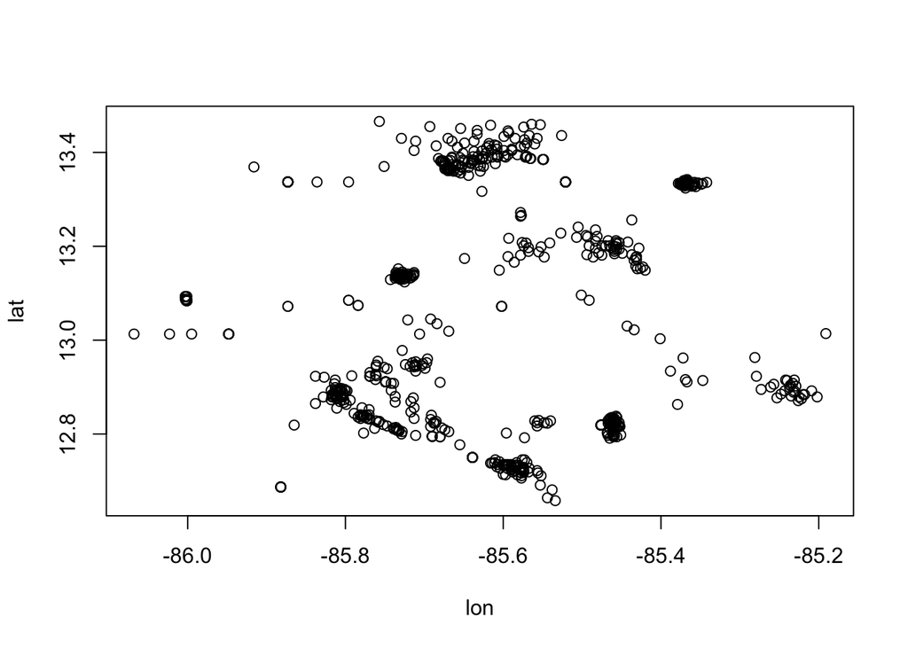

```r
plot(beans[,c("lon", "lat")])
```

The output is not so informative as it is simply a scatterplot where the axys Y is the latitude and X is the longitude. We can improve this visualization by applying a layer of geographic coverage to get an idea where these trials were set. We use an internal function of the ClimMob workflow powered by the package leaflet.

```r
plot_map(beans, c("lon", "lat"), map_provider = "OpenStreetMap.Mapnik")
```

[interactive chart not shown]

## Rank visualization

First we coerce the tricot rankings into a PlackettLuce rankings

```r
R <- rank_tricot(data = beans,
                 items = c("variety_a","variety_b","variety_c"),
                 input = c("best","worst"))
head(R)
```

```
## [1] "PM2 Don Rey > SJC 730-79 > BRT 103-182"
## [2] "INTA Centro Sur > INTA Sequia > INTA ..."
## [3] "INTA Ferroso > INTA Matagalpa > BRT  ..."
## [4] "INTA Rojo > INTA Centro Sur > ALS 0532-6"
## [5] "PM2 Don Rey > INTA Sequia > SJC 730-79"
## [6] "ALS 0532-6 > INTA Matagalpa > INTA Rojo"
```

We can see the network (how these varieties are connected) of this trial by computing the adjacency of rankings with the function `adjacency()` from PlackettLuce and the function `network()` from the ClimMob workflow.

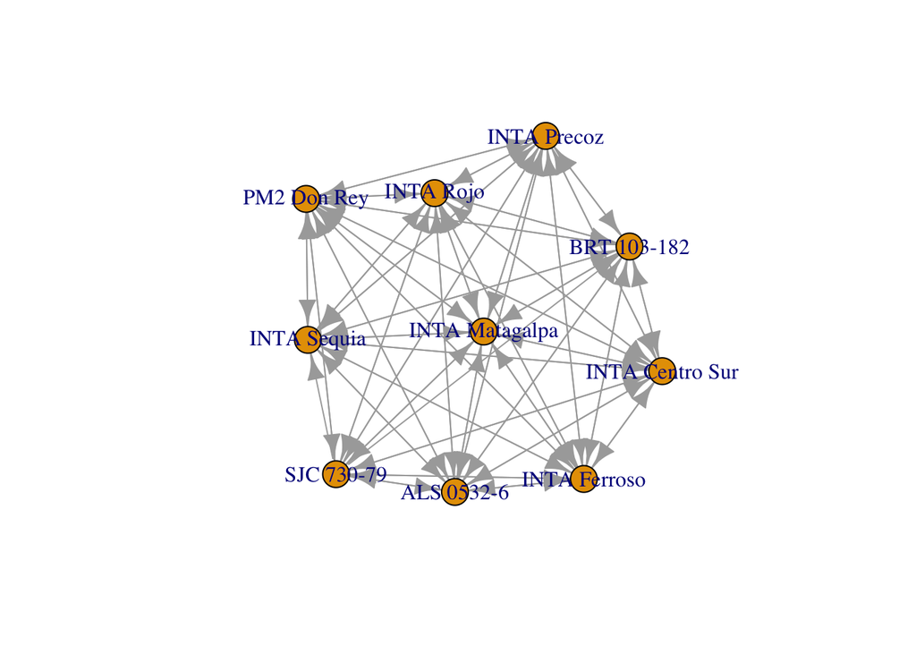

```r
a <- adjacency(R)

a <- network(a)

plot(a)
```

### Favourability score

The function `summarise_favourite()` computes the favourability score from permutations contests. The favourability score is the difference between the wins and losses of a given item in a paired comparison.

```r
fav <- summarise_favourite(R)

fav
```

```
## # A tibble: 10 x 6
##    items               N  best worst  wins fav_score
##    <chr>           <int> <dbl> <dbl> <dbl>     <dbl>
##  1 INTA Sequia       259  41.3  24.7  75.3     16.6
##  2 INTA Centro Sur   260  37.3  28.1  71.9      9.23
##  3 BRT 103-182       245  38.8  33.5  66.5      5.31
##  4 INTA Rojo         249  33.7  30.9  69.1      2.81
##  5 INTA Matagalpa    258  31.8  34.1  65.9     -2.33
##  6 PM2 Don Rey       244  31.1  35.2  64.8     -4.10
##  7 INTA Ferroso      234  29.9  35.0  65.0     -5.13
##  8 SJC 730-79        270  31.1  36.3  63.7     -5.19
##  9 ALS 0532-6        261  30.3  39.1  60.9     -8.81
## 10 INTA Precoz       246  27.6  36.6  63.4     -8.94
```

It has a plot method powered by the package [ggplot2](https://ggplot2.tidyverse.org/) which offer many options to change its layout.

```r
plot(fav) +
  theme_bw() +
  theme(panel.grid = element_blank())
```

[figure not shown]

### Victories

The function `summarise_victories()` summarises the relative number of times a “player1” wins against a “player2” in a paired comparison.

```r
vic <- summarise_victories(R)

head(vic)
```

```
##       player1         player2 win ncontest victories
## 1  ALS 0532-6     BRT 103-182  27       64 0.4218750
## 2  ALS 0532-6 INTA Centro Sur  21       58 0.3620690
## 4  ALS 0532-6    INTA Ferroso  29       53 0.5471698
## 7  ALS 0532-6  INTA Matagalpa  29       54 0.5370370
## 11 ALS 0532-6     INTA Precoz  27       55 0.4909091
## 16 ALS 0532-6       INTA Rojo  34       63 0.5396825
```

Also with a plot method that passes ggplot2 arguments

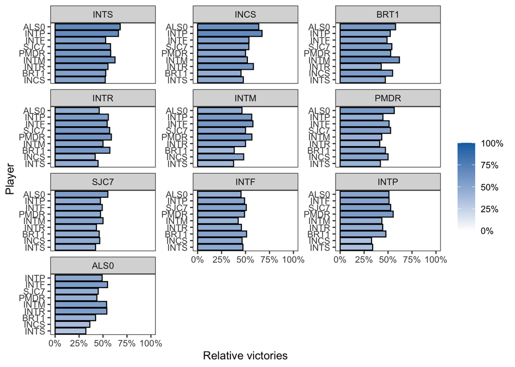

```r
plot(vic) +
  theme_bw() +
  theme(panel.grid = element_blank())
```

# Example 2: Sweetpotato data

This is the data from [Moyo et al (2021)](https://doi.org/10.3389/fsufs.2021.620363) who tested the consumers’ preference on sweetpotato materials (varieties and genotypes) in Ghana and Uganda. The data is available [here](https://doi.org/10.5281/zenodo.4012057) and also in the classroom materials in the “data/” folder.

We first read the .csv file with the function `read.csv()`

```r
dt <- read.csv("data/sweet_potato.csv")
```

```r
str(dt)
```

```
## 'data.frame':    1433 obs. of  20 variables:
##  $ id            : int  6 18 24 25 27 56 62 63 73 74 ...
##  $ country       : chr  "Uganda" "Uganda" "Uganda" "Uganda" ...
##  $ district      : chr  "Gulu" "Gulu" "Gulu" "Gulu" ...
##  $ gender        : chr  "Woman" "Woman" "Man" "Man" ...
##  $ trial         : chr  "community" "community" "community" "community" ...
##  $ item_A        : chr  "NASPOT 10 (Kabode)" "Kakamega" "NASPOT 13" "NASPOT 12" ...
##  $ item_B        : chr  "NASPOT 12" "NASPOT 8" "NASPOT 10 (Kabode)" "NASPOT 10 (Kabode)" ...
##  $ item_C        : chr  "NASPOT 13" "NASPOT 13" "Kakamega" "NASPOT 13" ...
##  $ best_overall  : chr  "B" "B" "A" "A" ...
##  $ worst_overall : chr  "A" "A" "C" "B" ...
##  $ best_taste    : chr  "C" "B" "A" "A" ...
##  $ worst_taste   : chr  "B" "C" "C" "B" ...
##  $ best_color    : chr  "B" "C" "B" "C" ...
##  $ worst_color   : chr  "C" "B" "A" "A" ...
##  $ best_describe : chr  "It has high dry matter content" "nice, sweet" "sweet" "very sweet and nice" ...
##  $ worst_describe: chr  "not too sweet" "sweet" "wet" "it is wet and not sweet" ...
##  $ community     : chr  NA NA NA NA ...
##  $ age           : chr  NA NA NA NA ...
##  $ geno_test     : chr  NA NA NA NA ...
##  $ region        : chr  NA NA NA NA ...
```

## Agreement between rankings

We are going to compare rankings from the three traits evaluated in the sweetpotato trial (taste, color and overall) using overall as baseline. We use the function `summarise_agreement()` which computes the [Kendall correlation](https://en.wikipedia.org/wiki/Kendall_rank_correlation_coefficient) between rankings, and the agreement between the first and last ranked varieties.

First, we subset the main dataset to retain only the Uganda data. The condition `dt$country == "Uganda"` passed in the rows of `dt` return a logical vector (`TRUE FALSE`) for the observations in `dt$country` that are equal to Uganda.

```r
keep <- dt$country == "Uganda"

dt <- dt[keep, ]

dim(dt)
```

```
## [1] 418  20
```

Now we isolate the strings for the traits assessed in Uganda. We use the function `paste0()` to create a vector that represents the traits and their names in `dt` with the strings `best_` and `worst_`

```r
traits <- c("overall","taste","color")

sel <- paste0(c("best_","worst_"), rep(traits, each = 2))

sel
```

```
## [1] "best_overall"  "worst_overall" "best_taste"    "worst_taste"
## [5] "best_color"    "worst_color"
```

We use an [iteration](https://r4ds.had.co.nz/iteration.html) with `for` to create the rankings. Iterations are often used to optimize processes and enable a better debugging structure

We create an empty list and the rankings that are going to be created in each iteration `i` performed along the vector `traits`

```r
R <- list()

for(i in seq_along(traits)){

  R[[i]] <- rank_tricot(dt,
                        items = c("item_A", "item_B", "item_C"),
                        input = paste0(c("best_","worst_"), traits[[i]]))

}
```

We can now compare the rankings. The first argument is the baseline wich is the first element in the list `R`, we indicate it with `R[[1]]` where 1 is the index for the first element in the list. The second argument is the list with rankings to compare, we indicate it with `R[-1]` where -1 tells to R to use all the elements in the list besides the first.

```r
a <- summarise_agreement(R[[1]],
                         compare.to = R[-1],
                         labels = c("Taste","Colour"))

a
```

```
## # A tibble: 2 x 4
##   labels kendall first  last
##   <chr>    <dbl> <dbl> <dbl>
## 1 Taste    79.9   88.5  81.3
## 2 Colour   -3.19  27.0  18.2
```

We can also plot it with the ggplot2 methods

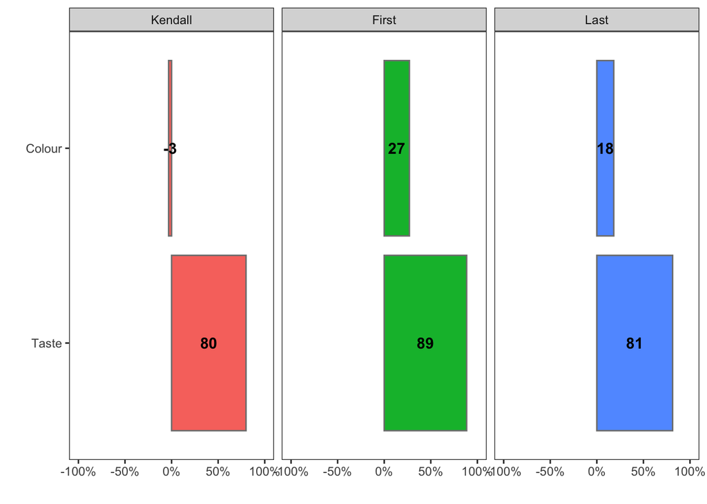

[figure not shown]

```r
plot(a) +
  theme_bw() +
  theme(panel.grid = element_blank())
```

desousakaue k.desousa@cgiar.org